# INLA scale code study

Hashan Fernando

2024-03-06

```r
library(INLA)
df <- read.csv("matrix_data.csv", header = FALSE)
mat <- as.matrix(df)
mat
```

```
##       V1 V2 V3 V4 V5 V6 V7 V8 V9 V10 V11 V12
##  [1,]  3 -1 -1  0  0 -1  0  0  0   0   0   0
##  [2,] -1  4 -1 -1  0  0  0  0  0   0   0  -1
##  [3,] -1 -1  4 -1  0  0  0 -1  0   0   0   0
##  [4,]  0 -1 -1  4  0  0  0 -1  0   0   0  -1
##  [5,]  0  0  0  0  2  0  0  0  0   0  -1  -1
##  [6,] -1  0  0  0  0  1  0  0  0   0   0   0
##  [7,]  0  0  0  0  0  0  4 -1 -1  -1  -1   0
##  [8,]  0  0 -1 -1  0  0 -1  6 -1   0  -1  -1
##  [9,]  0  0  0  0  0  0 -1 -1  3  -1   0   0
## [10,]  0  0  0  0  0  0 -1  0 -1   2   0   0
## [11,]  0  0  0  0 -1  0 -1 -1  0   0   4  -1
## [12,]  0 -1  0 -1 -1  0  0 -1  0   0  -1   5
```

```r
P = inla.scale.model(mat, constr=list(A=matrix(1, nrow=1, ncol=12),e=0))
P
```

```
## 12 x 12 sparse Matrix of class "dgTMatrix"
```

```
##   [[ suppressing 12 column names 'V1', 'V2', 'V3' ... ]]
```

```
##
##  [1,]  1.2003033 -0.4001011 -0.4001011  .          .         -0.4001011
##  [2,] -0.4001011  1.6004044 -0.4001011 -0.4001011  .          .
##  [3,] -0.4001011 -0.4001011  1.6004044 -0.4001011  .          .
##  [4,]  .         -0.4001011 -0.4001011  1.6004044  .          .
##  [5,]  .          .          .          .          0.8002022  .
##  [6,] -0.4001011  .          .          .          .          0.4001011
##  [7,]  .          .          .          .          .          .
##  [8,]  .          .         -0.4001011 -0.4001011  .          .
##  [9,]  .          .          .          .          .          .
## [10,]  .          .          .          .          .          .
## [11,]  .          .          .          .         -0.4001011  .
## [12,]  .         -0.4001011  .         -0.4001011 -0.4001011  .
##
##  [1,]  .          .          .          .          .          .
##  [2,]  .          .          .          .          .         -0.4001011
##  [3,]  .         -0.4001011  .          .          .          .
##  [4,]  .         -0.4001011  .          .          .         -0.4001011
##  [5,]  .          .          .          .         -0.4001011 -0.4001011
##  [6,]  .          .          .          .          .          .
##  [7,]  1.6004044 -0.4001011 -0.4001011 -0.4001011 -0.4001011  .
##  [8,] -0.4001011  2.4006066 -0.4001011  .         -0.4001011 -0.4001011
##  [9,] -0.4001011 -0.4001011  1.2003033 -0.4001011  .          .
## [10,] -0.4001011  .         -0.4001011  0.8002022  .          .
## [11,] -0.4001011 -0.4001011  .          .          1.6004044 -0.4001011
## [12,]  .         -0.4001011  .          .         -0.4001011  2.0005055
```

Geometric mean checking

```r
# Initialize a vector to store the log sums of diagonal elements
log_diag_sums <- numeric(12)

# Loop through each diagonal element
for (i in 1:12) {
  log_diag_sums[i] <- log(P[i, i])
}

#print(log_diag_sums)
#print(mean(log_diag_sums))
print(exp(mean(log_diag_sums)))
```

```
## [1] 1.27589
```

inla.scale.model Study

Inputs,  
Q,  
constr = NULL,  
eps = sqrt(.Machine$double.eps)

```r
print(.Machine$double.eps)
```

```
## [1] 2.220446e-16
```

```r
print(sqrt(.Machine$double.eps))
```

```
## [1] 1.490116e-08
```

Need to study inla.scale.model.internal  
Same Inputs

Let’s define df as Q,

```r
Q = mat
Q
```

```
##       V1 V2 V3 V4 V5 V6 V7 V8 V9 V10 V11 V12
##  [1,]  3 -1 -1  0  0 -1  0  0  0   0   0   0
##  [2,] -1  4 -1 -1  0  0  0  0  0   0   0  -1
##  [3,] -1 -1  4 -1  0  0  0 -1  0   0   0   0
##  [4,]  0 -1 -1  4  0  0  0 -1  0   0   0  -1
##  [5,]  0  0  0  0  2  0  0  0  0   0  -1  -1
##  [6,] -1  0  0  0  0  1  0  0  0   0   0   0
##  [7,]  0  0  0  0  0  0  4 -1 -1  -1  -1   0
##  [8,]  0  0 -1 -1  0  0 -1  6 -1   0  -1  -1
##  [9,]  0  0  0  0  0  0 -1 -1  3  -1   0   0
## [10,]  0  0  0  0  0  0 -1  0 -1   2   0   0
## [11,]  0  0  0  0 -1  0 -1 -1  0   0   4  -1
## [12,]  0 -1  0 -1 -1  0  0 -1  0   0  -1   5
```

```r
nrow(Q)
```

```
## [1] 12
```

define 12 element vector of 0 rep() function is used to replicate elements of vectors or array

```r
marg.var <- rep(0, nrow(Q))
marg.var
```

```
##  [1] 0 0 0 0 0 0 0 0 0 0 0 0
```

inla.as.sparse(Q) same as dgTMatrix

dgTMatrix format: The dgTMatrix format is a compressed representation of a sparse matrix, particularly efficient for matrices with a large number of zero elements. It stores only the non-zero elements and their positions, making it memory-efficient and suitable for various mathematical operations

```r
Q_sparse <- inla.as.sparse(Q)
Q_sparse
```

```
## 12 x 12 sparse Matrix of class "dgTMatrix"
```

```
##   [[ suppressing 12 column names 'V1', 'V2', 'V3' ... ]]
```

```
##
##  [1,]  3 -1 -1  .  . -1  .  .  .  .  .  .
##  [2,] -1  4 -1 -1  .  .  .  .  .  .  . -1
##  [3,] -1 -1  4 -1  .  .  . -1  .  .  .  .
##  [4,]  . -1 -1  4  .  .  . -1  .  .  . -1
##  [5,]  .  .  .  .  2  .  .  .  .  . -1 -1
##  [6,] -1  .  .  .  .  1  .  .  .  .  .  .
##  [7,]  .  .  .  .  .  .  4 -1 -1 -1 -1  .
##  [8,]  .  . -1 -1  .  . -1  6 -1  . -1 -1
##  [9,]  .  .  .  .  .  . -1 -1  3 -1  .  .
## [10,]  .  .  .  .  .  . -1  . -1  2  .  .
## [11,]  .  .  .  . -1  . -1 -1  .  .  4 -1
## [12,]  . -1  . -1 -1  .  . -1  .  . -1  5
```

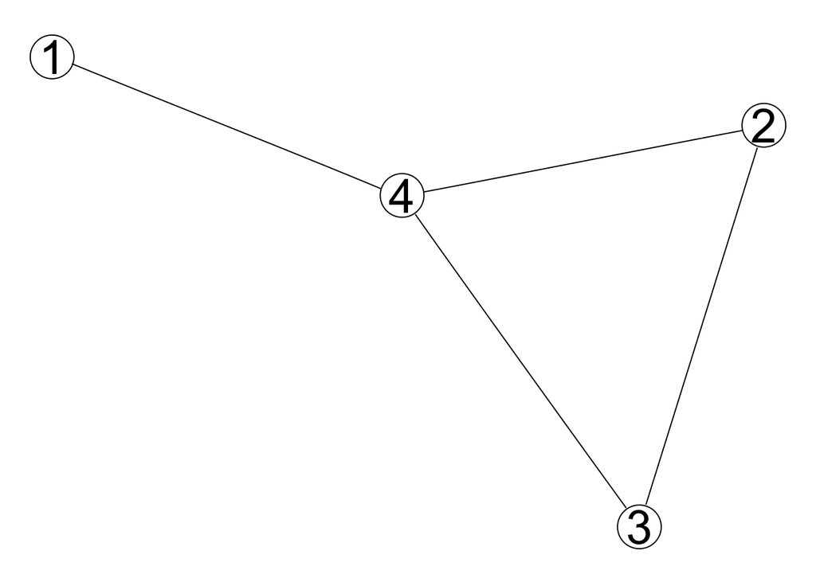

```r
## building a graph from adjacency matrix
adjacent = matrix(0, nrow = 4, ncol = 4)
adjacent[1,4] = adjacent[4,1] = 1
adjacent[2,4] = adjacent[4,2] = 1
adjacent[2,3] = adjacent[3,2] = 1
adjacent[3,4] = adjacent[4,3] = 1
g_ = inla.read.graph(adjacent)
plot(g_)
```

```r
summary(g_)
```

```
##  n =  4
##  ncc =  1
##  nnbs = (names)  1 2 3
##         (count)  1 2 1
```

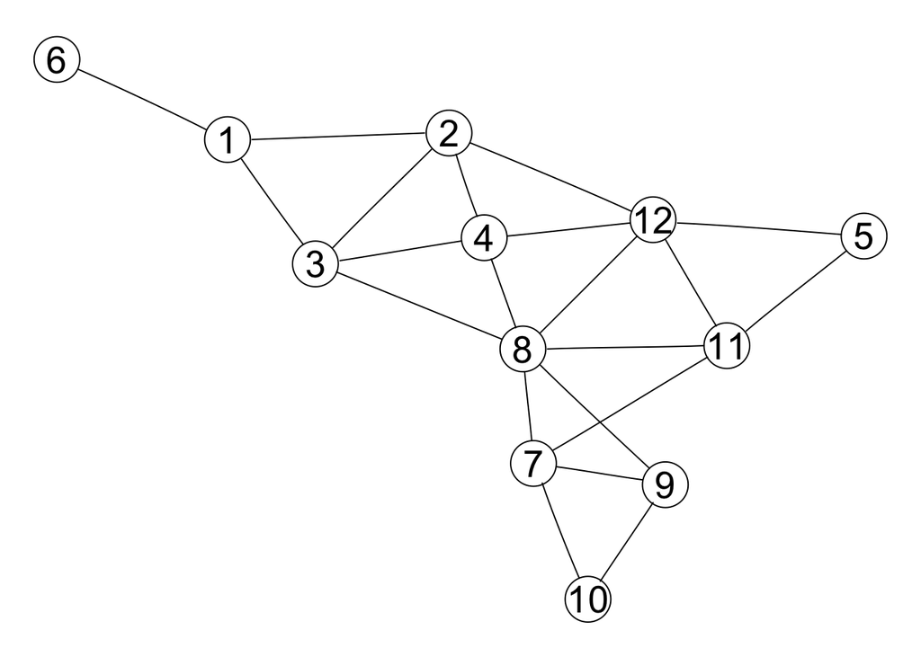

```r
g <- inla.read.graph(Q_sparse)
plot(g)
```

```r
summary(g)
```

```
##  n =  12
##  ncc =  1
##  nnbs = (names)  1 2 3 4 5 6
##         (count)  1 2 2 5 1 1
```

```r
help(inla.read.graph)
```

INLA graph function

We need g$cc$n  
and g$cc$nodes

```r
print(g$cc$n)
```

```
## [1] 1
```

```r
print(g$cc$nodes )
```

```
## [[1]]
##  [1]  1  2  3  4  5  6  7  8  9 10 11 12
```

```r
i <- g$cc$nodes[[1]]
print(i)
```

```
##  [1]  1  2  3  4  5  6  7  8  9 10 11 12
```

```r
n <- length(i)


# This indicates that we are selecting rows and columns from the matrix specified by the indices i. Since i is used for both rows and columns,
QQ <- Q_sparse[i, i, drop = FALSE]


if (n == 1) {
  QQ[1, 1] <- 1
  marg.var[i] <- 1
}
```

```r
QQ
```

```
## 12 x 12 sparse Matrix of class "dgTMatrix"
```

```
##   [[ suppressing 12 column names 'V1', 'V2', 'V3' ... ]]
```

```
##
##  [1,]  3 -1 -1  .  . -1  .  .  .  .  .  .
##  [2,] -1  4 -1 -1  .  .  .  .  .  .  . -1
##  [3,] -1 -1  4 -1  .  .  . -1  .  .  .  .
##  [4,]  . -1 -1  4  .  .  . -1  .  .  . -1
##  [5,]  .  .  .  .  2  .  .  .  .  . -1 -1
##  [6,] -1  .  .  .  .  1  .  .  .  .  .  .
##  [7,]  .  .  .  .  .  .  4 -1 -1 -1 -1  .
##  [8,]  .  . -1 -1  .  . -1  6 -1  . -1 -1
##  [9,]  .  .  .  .  .  . -1 -1  3 -1  .  .
## [10,]  .  .  .  .  .  . -1  . -1  2  .  .
## [11,]  .  .  .  . -1  . -1 -1  .  .  4 -1
## [12,]  . -1  . -1 -1  .  . -1  .  . -1  5
```

Else part(important)

```r
L =list(A=matrix(1, nrow=1, ncol=12))
L
```

```
## $A
##      [,1] [,2] [,3] [,4] [,5] [,6] [,7] [,8] [,9] [,10] [,11] [,12]
## [1,]    1    1    1    1    1    1    1    1    1     1     1     1
```

constr  
Linear constraints spanning the null-space of Q; see ?INLA::f and argument extraconstr

When we talk about linear constraints spanning the null-space of the Q matrix, it means that we are imposing linear restrictions on the variables represented by x such that the resulting vector lies in the null-space of Q. In other words, these constraints are defining relationships between the variables such that the resulting combination satisfies the equation Qx=0.

For example, if Q is a coefficient matrix representing a system of linear equations, the null-space contains all the solutions to the homogeneous system Qx=0. In this context, linear constraints spanning the null-space could refer to additional conditions imposed on the variables to ensure that they satisfy the given system of equations. These constraints would help define the solution space more precisely.

eps A small constant added to the diagonal of Q if constr

```r
constr = L
eps = sqrt(.Machine$double.eps)

cconstr <- constr

if (!is.null(constr)) {
    cconstr$A <- constr$A[, i, drop = FALSE]
    eeps <- eps
}else {
    eeps <- 0
}
```

```r
constr$A
```

```
##      [,1] [,2] [,3] [,4] [,5] [,6] [,7] [,8] [,9] [,10] [,11] [,12]
## [1,]    1    1    1    1    1    1    1    1    1     1     1     1
```

The which() function in R returns the indices of the elements that satisfy a given condition. In this specific case, which(rowSums(abs(cconstr$A)) == 0) will return the indices of the rows in the matrix cconstr$A where the sum of the absolute values of elements across each row equals zero.

```r
idx.zero <- which(rowSums(abs(cconstr$A)) == 0)
print(idx.zero)
```

```
## integer(0)
```

```r
if (length(idx.zero) > 0) {
    #This line removes the rows indexed by idx.zero from the matrix cconstr$A. The -idx.zero notation is used to index all rows except those specified in idx.zero. The drop = FALSE argument ensures that the result remains a matrix even if it has only one row.
    cconstr$A <- cconstr$A[-idx.zero, , drop = FALSE]
    #  This line removes the elements indexed by idx.zero from the vector cconstr$e
    cconstr$e <- cconstr$e[-idx.zero]
}
```

```r
Diagonal(n)
```

```
## 12 x 12 diagonal matrix of class "ddiMatrix"
##       [,1] [,2] [,3] [,4] [,5] [,6] [,7] [,8] [,9] [,10] [,11] [,12]
##  [1,]    1    .    .    .    .    .    .    .    .     .     .     .
##  [2,]    .    1    .    .    .    .    .    .    .     .     .     .
##  [3,]    .    .    1    .    .    .    .    .    .     .     .     .
##  [4,]    .    .    .    1    .    .    .    .    .     .     .     .
##  [5,]    .    .    .    .    1    .    .    .    .     .     .     .
##  [6,]    .    .    .    .    .    1    .    .    .     .     .     .
##  [7,]    .    .    .    .    .    .    1    .    .     .     .     .
##  [8,]    .    .    .    .    .    .    .    1    .     .     .     .
##  [9,]    .    .    .    .    .    .    .    .    1     .     .     .
## [10,]    .    .    .    .    .    .    .    .    .     1     .     .
## [11,]    .    .    .    .    .    .    .    .    .     .     1     .
## [12,]    .    .    .    .    .    .    .    .    .     .     .     1
```

```r
max(diag(QQ))
```

```
## [1] 6
```

```r
Diagonal(n)*max(diag(QQ))*eeps
```

```
## 12 x 12 diagonal matrix of class "ddiMatrix"
##       [,1]         [,2]         [,3]         [,4]         [,5]
##  [1,] 8.940697e-08            .            .            .            .
##  [2,]            . 8.940697e-08            .            .            .
##  [3,]            .            . 8.940697e-08            .            .
##  [4,]            .            .            . 8.940697e-08            .
##  [5,]            .            .            .            . 8.940697e-08
##  [6,]            .            .            .            .            .
##  [7,]            .            .            .            .            .
##  [8,]            .            .            .            .            .
##  [9,]            .            .            .            .            .
## [10,]            .            .            .            .            .
## [11,]            .            .            .            .            .
## [12,]            .            .            .            .            .
##       [,6]         [,7]         [,8]         [,9]         [,10]
```

[output cut: 25 more lines]

```r
QQ+Diagonal(n)*max(diag(QQ))*eeps
```

```
## 12 x 12 sparse Matrix of class "dgCMatrix"
```

```
##   [[ suppressing 12 column names 'V1', 'V2', 'V3' ... ]]
```

```
##
##  [1,]  3 -1 -1  .  . -1  .  .  .  .  .  .
##  [2,] -1  4 -1 -1  .  .  .  .  .  .  . -1
##  [3,] -1 -1  4 -1  .  .  . -1  .  .  .  .
##  [4,]  . -1 -1  4  .  .  . -1  .  .  . -1
##  [5,]  .  .  .  .  2  .  .  .  .  . -1 -1
##  [6,] -1  .  .  .  .  1  .  .  .  .  .  .
##  [7,]  .  .  .  .  .  .  4 -1 -1 -1 -1  .
##  [8,]  .  . -1 -1  .  . -1  6 -1  . -1 -1
##  [9,]  .  .  .  .  .  . -1 -1  3 -1  .  .
## [10,]  .  .  .  .  .  . -1  . -1  2  .  .
## [11,]  .  .  .  . -1  . -1 -1  .  .  4 -1
## [12,]  . -1  . -1 -1  .  . -1  .  . -1  5
```

Have to define this as 0. Look the function e=0

```r
cconstr$e <-0
```

```r
res <- inla.qinv(QQ + Diagonal(n)*max(diag(QQ))*eeps,constr = cconstr)
res
```

```
## 12 x 12 sparse Matrix of class "dgTMatrix"
##
##  [1,] 0.5295787 0.11550539  0.110318674 .          .         0.4462453
##  [2,] 0.1155054 0.30516653  0.092510936 0.07383874 .         .
##  [3,] 0.1103187 0.09251094  0.294793091 0.06865202 .         .
##  [4,] .         0.07383874  0.068652020 0.27957871 .         .
##  [5,] .         .           .           .          0.5791407 .
##  [6,] 0.4462453 .           .           .          .         1.3629118
##  [7,] .         .           .           .          .         .
##  [8,] .         .          -0.008975907 0.01661192 .         .
##  [9,] .         .           .           .          .         .
## [10,] .         .           .           .          .         .
## [11,] .         .           .           .          0.1386151 .
## [12,] .         0.02214442  .           0.04254552 0.1029996 .
##
##  [1,] .           .           .          .         .          .
##  [2,] .           .           .          .         .          0.02214442
##  [3,] .          -0.008975907 .          .         .          .
##  [4,] .           0.016611917 .          .         .          0.04254552
##  [5,] .           .           .          .         0.13861513 0.10299964
##  [6,] .           .           .          .         .          .
##  [7,] 0.36198994  0.048711953 0.18667873 0.2326677 0.06323477 .
##  [8,] 0.04871195  0.180339434 0.05136294 .         0.03810799 0.01955106
##  [9,] 0.18667873  0.051362944 0.48255239 0.2929489 .          .
## [10,] 0.23266766  .           0.29294888 0.7211416 .          .
## [11,] 0.06323477  0.038107991 .          .         0.30343762 0.05712597
## [12,] .           0.019551057 .          .         0.05712597 0.23220665
```

```r
fac <- exp(mean(log(diag(res))))
fac
```

```
## [1] 0.4001011
```

```r
QQ_ <- fac * QQ
QQ_
```

```
## 12 x 12 sparse Matrix of class "dgCMatrix"
```

```
##   [[ suppressing 12 column names 'V1', 'V2', 'V3' ... ]]
```

```
##
##  [1,]  1.2003033 -0.4001011 -0.4001011  .          .         -0.4001011
##  [2,] -0.4001011  1.6004044 -0.4001011 -0.4001011  .          .
##  [3,] -0.4001011 -0.4001011  1.6004044 -0.4001011  .          .
##  [4,]  .         -0.4001011 -0.4001011  1.6004044  .          .
##  [5,]  .          .          .          .          0.8002022  .
##  [6,] -0.4001011  .          .          .          .          0.4001011
##  [7,]  .          .          .          .          .          .
##  [8,]  .          .         -0.4001011 -0.4001011  .          .
##  [9,]  .          .          .          .          .          .
## [10,]  .          .          .          .          .          .
## [11,]  .          .          .          .         -0.4001011  .
## [12,]  .         -0.4001011  .         -0.4001011 -0.4001011  .
##
##  [1,]  .          .          .          .          .          .
##  [2,]  .          .          .          .          .         -0.4001011
##  [3,]  .         -0.4001011  .          .          .          .
##  [4,]  .         -0.4001011  .          .          .         -0.4001011
##  [5,]  .          .          .          .         -0.4001011 -0.4001011
##  [6,]  .          .          .          .          .          .
##  [7,]  1.6004044 -0.4001011 -0.4001011 -0.4001011 -0.4001011  .
##  [8,] -0.4001011  2.4006066 -0.4001011  .         -0.4001011 -0.4001011
##  [9,] -0.4001011 -0.4001011  1.2003033 -0.4001011  .          .
## [10,] -0.4001011  .         -0.4001011  0.8002022  .          .
## [11,] -0.4001011 -0.4001011  .          .          1.6004044 -0.4001011
## [12,]  .         -0.4001011  .          .         -0.4001011  2.0005055
```

```r
Q_sparse[c(1,2), c(1,2), drop = FALSE]
```

```
## 2 x 2 sparse Matrix of class "dgTMatrix"
##      V1 V2
## [1,]  3 -1
## [2,] -1  4
```

```r
marg.var[i] <- diag(res)/fac
marg.var
```

```
##  [1] 1.3236121 0.7627236 0.7367965 0.6987702 1.4474859 3.4064186 0.9047462
##  [8] 0.4507347 1.2060762 1.8023984 0.7584024 0.5803699
```

```r
Q
```

```
##       V1 V2 V3 V4 V5 V6 V7 V8 V9 V10 V11 V12
##  [1,]  3 -1 -1  0  0 -1  0  0  0   0   0   0
##  [2,] -1  4 -1 -1  0  0  0  0  0   0   0  -1
##  [3,] -1 -1  4 -1  0  0  0 -1  0   0   0   0
##  [4,]  0 -1 -1  4  0  0  0 -1  0   0   0  -1
##  [5,]  0  0  0  0  2  0  0  0  0   0  -1  -1
##  [6,] -1  0  0  0  0  1  0  0  0   0   0   0
##  [7,]  0  0  0  0  0  0  4 -1 -1  -1  -1   0
##  [8,]  0  0 -1 -1  0  0 -1  6 -1   0  -1  -1
##  [9,]  0  0  0  0  0  0 -1 -1  3  -1   0   0
## [10,]  0  0  0  0  0  0 -1  0 -1   2   0   0
## [11,]  0  0  0  0 -1  0 -1 -1  0   0   4  -1
## [12,]  0 -1  0 -1 -1  0  0 -1  0   0  -1   5
```

```r
QQ_
```

```
## 12 x 12 sparse Matrix of class "dgCMatrix"
```

```
##   [[ suppressing 12 column names 'V1', 'V2', 'V3' ... ]]
```

```
##
##  [1,]  1.2003033 -0.4001011 -0.4001011  .          .         -0.4001011
##  [2,] -0.4001011  1.6004044 -0.4001011 -0.4001011  .          .
##  [3,] -0.4001011 -0.4001011  1.6004044 -0.4001011  .          .
##  [4,]  .         -0.4001011 -0.4001011  1.6004044  .          .
##  [5,]  .          .          .          .          0.8002022  .
##  [6,] -0.4001011  .          .          .          .          0.4001011
##  [7,]  .          .          .          .          .          .
##  [8,]  .          .         -0.4001011 -0.4001011  .          .
##  [9,]  .          .          .          .          .          .
## [10,]  .          .          .          .          .          .
## [11,]  .          .          .          .         -0.4001011  .
## [12,]  .         -0.4001011  .         -0.4001011 -0.4001011  .
##
##  [1,]  .          .          .          .          .          .
##  [2,]  .          .          .          .          .         -0.4001011
##  [3,]  .         -0.4001011  .          .          .          .
##  [4,]  .         -0.4001011  .          .          .         -0.4001011
##  [5,]  .          .          .          .         -0.4001011 -0.4001011
##  [6,]  .          .          .          .          .          .
##  [7,]  1.6004044 -0.4001011 -0.4001011 -0.4001011 -0.4001011  .
##  [8,] -0.4001011  2.4006066 -0.4001011  .         -0.4001011 -0.4001011
##  [9,] -0.4001011 -0.4001011  1.2003033 -0.4001011  .          .
## [10,] -0.4001011  .         -0.4001011  0.8002022  .          .
## [11,] -0.4001011 -0.4001011  .          .          1.6004044 -0.4001011
## [12,]  .         -0.4001011  .          .         -0.4001011  2.0005055
```

```r
# Check the number of rows
num_rows <- nrow(Q)

# Check the number of columns
num_cols <- ncol(Q)

# Print the number of rows and columns
print(num_rows)
```

```
## [1] 12
```

```r
print(num_cols)
```

```
## [1] 12
```

```r
# Check the number of rows
num_rows <- nrow(QQ_)

# Check the number of columns
num_cols <- ncol(QQ_)

# Print the number of rows and columns
print(num_rows)
```

```
## [1] 12
```

```r
print(num_cols)
```

```
## [1] 12
```

```r
#Q[i, i] <- QQ_
```

```r
my_function <- function (Q, constr = NULL, eps = sqrt(.Machine$double.eps))
{
    marg.var <- rep(0, nrow(Q))
    Q <- inla.as.sparse(Q)
    g <- inla.read.graph(Q)
    for (k in seq_len(g$cc$n)) {
        i <- g$cc$nodes[[k]]
        n <- length(i)
        QQ <- Q[i, i, drop = FALSE]
        if (n == 1) {
            QQ[1, 1] <- 1
            marg.var[i] <- 1
        }
        else {
            cconstr <- constr
            if (!is.null(constr)) {
                cconstr$A <- constr$A[, i, drop = FALSE]
                eeps <- eps
            }
            else {
                eeps <- 0
            }
            idx.zero <- which(rowSums(abs(cconstr$A)) == 0)
            if (length(idx.zero) > 0) {
                cconstr$A <- cconstr$A[-idx.zero, , drop = FALSE]
                cconstr$e <- cconstr$e[-idx.zero]
            }
            res <- inla.qinv(QQ + Diagonal(n) * max(diag(QQ)) *
                eeps, constr = cconstr)
            fac <- exp(mean(log(diag(res))))
            QQ <- fac * QQ
            marg.var[i] <- diag(res)/fac
        }

        #print(Q)
        #print(QQ)
        Q[i, i] <- QQ
        print(Q)
    }
    return(list(Q = Q, var = marg.var))
}
```

```r
T = my_function(mat, constr=list(A=matrix(1, nrow=1, ncol=12),e=0))
```

```
## 12 x 12 sparse Matrix of class "dgTMatrix"
```

```
##   [[ suppressing 12 column names 'V1', 'V2', 'V3' ... ]]
```

```
##
##  [1,]  1.2003033 -0.4001011 -0.4001011  .          .         -0.4001011
##  [2,] -0.4001011  1.6004044 -0.4001011 -0.4001011  .          .
##  [3,] -0.4001011 -0.4001011  1.6004044 -0.4001011  .          .
##  [4,]  .         -0.4001011 -0.4001011  1.6004044  .          .
##  [5,]  .          .          .          .          0.8002022  .
##  [6,] -0.4001011  .          .          .          .          0.4001011
##  [7,]  .          .          .          .          .          .
##  [8,]  .          .         -0.4001011 -0.4001011  .          .
##  [9,]  .          .          .          .          .          .
## [10,]  .          .          .          .          .          .
## [11,]  .          .          .          .         -0.4001011  .
## [12,]  .         -0.4001011  .         -0.4001011 -0.4001011  .
##
##  [1,]  .          .          .          .          .          .
##  [2,]  .          .          .          .          .         -0.4001011
##  [3,]  .         -0.4001011  .          .          .          .
##  [4,]  .         -0.4001011  .          .          .         -0.4001011
##  [5,]  .          .          .          .         -0.4001011 -0.4001011
##  [6,]  .          .          .          .          .          .
##  [7,]  1.6004044 -0.4001011 -0.4001011 -0.4001011 -0.4001011  .
##  [8,] -0.4001011  2.4006066 -0.4001011  .         -0.4001011 -0.4001011
##  [9,] -0.4001011 -0.4001011  1.2003033 -0.4001011  .          .
## [10,] -0.4001011  .         -0.4001011  0.8002022  .          .
## [11,] -0.4001011 -0.4001011  .          .          1.6004044 -0.4001011
## [12,]  .         -0.4001011  .          .         -0.4001011  2.0005055
```

```r
T
```

```
## $Q
## 12 x 12 sparse Matrix of class "dgTMatrix"
```

```
##   [[ suppressing 12 column names 'V1', 'V2', 'V3' ... ]]
```

```
##
##  [1,]  1.2003033 -0.4001011 -0.4001011  .          .         -0.4001011
##  [2,] -0.4001011  1.6004044 -0.4001011 -0.4001011  .          .
##  [3,] -0.4001011 -0.4001011  1.6004044 -0.4001011  .          .
##  [4,]  .         -0.4001011 -0.4001011  1.6004044  .          .
##  [5,]  .          .          .          .          0.8002022  .
##  [6,] -0.4001011  .          .          .          .          0.4001011
##  [7,]  .          .          .          .          .          .
##  [8,]  .          .         -0.4001011 -0.4001011  .          .
##  [9,]  .          .          .          .          .          .
## [10,]  .          .          .          .          .          .
## [11,]  .          .          .          .         -0.4001011  .
## [12,]  .         -0.4001011  .         -0.4001011 -0.4001011  .
##
##  [1,]  .          .          .          .          .          .
##  [2,]  .          .          .          .          .         -0.4001011
##  [3,]  .         -0.4001011  .          .          .          .
##  [4,]  .         -0.4001011  .          .          .         -0.4001011
##  [5,]  .          .          .          .         -0.4001011 -0.4001011
##  [6,]  .          .          .          .          .          .
##  [7,]  1.6004044 -0.4001011 -0.4001011 -0.4001011 -0.4001011  .
##  [8,] -0.4001011  2.4006066 -0.4001011  .         -0.4001011 -0.4001011
##  [9,] -0.4001011 -0.4001011  1.2003033 -0.4001011  .          .
## [10,] -0.4001011  .         -0.4001011  0.8002022  .          .
## [11,] -0.4001011 -0.4001011  .          .          1.6004044 -0.4001011
## [12,]  .         -0.4001011  .          .         -0.4001011  2.0005055
##
## $var
##  [1] 1.3236121 0.7627236 0.7367965 0.6987702 1.4474859 3.4064186 0.9047462
##  [8] 0.4507347 1.2060762 1.8023984 0.7584024 0.5803699
```